# Assignment 5

This assignment has weighting $1.5$.

# Model tuning and evaluation

```python
# Added version check for recent scikit-learn 0.18 checks
from distutils.version import LooseVersion as Version
from sklearn import __version__ as sklearn_version
```

## Dataset

We will use the Wisconsin breast cancer dataset for the following questions

```python
import pandas as pd

wdbc_source = 'https://archive.ics.uci.edu/ml/machine-learning-databases/breast-cancer-wisconsin/wdbc.data'
#wdbc_source = '../datasets/wdbc/wdbc.data'

df = pd.read_csv(wdbc_source, header=None)
```

```python
from sklearn.preprocessing import LabelEncoder
X = df.loc[:, 2:].values
y = df.loc[:, 1].values
le = LabelEncoder()
y = le.fit_transform(y)
le.transform(['M', 'B'])
```

```
array([1, 0], dtype=int64)
```

```python
if Version(sklearn_version) < '0.18':
    from sklearn.cross_validation import train_test_split
else:
    from sklearn.model_selection import train_test_split

X_train, X_test, y_train, y_test = \
    train_test_split(X, y, test_size=0.20, random_state=1)
```

```python
%matplotlib inline
```

# K-fold validation (20 points)

Someone wrote the code below to conduct cross validation. Do you see anything wrong with it? And if so, correct the code and provide an explanation.

```python
import numpy as np
import copy
from sklearn.preprocessing import StandardScaler
from sklearn.decomposition import PCA
from sklearn.linear_model import Perceptron, LogisticRegression
from sklearn.pipeline import Pipeline

if Version(sklearn_version) < '0.18':
    from sklearn.cross_validation import StratifiedKFold
else:
    from sklearn.model_selection import StratifiedKFold

scl = StandardScaler()
pca = PCA(n_components=2)
clf = Perceptron(random_state=1)

# data preprocessing
X_train_std = scl.fit_transform(X_train)
X_test_std = scl.transform(X_test)

X_train_pca = pca.fit_transform(X_train_std)
X_test_pca = pca.transform(X_test_std)

# compute the data indices for each fold
if Version(sklearn_version) < '0.18':
    kfold = StratifiedKFold(y=y_train,
                            n_folds=10,
                            random_state=1)
else:
    kfold = StratifiedKFold(n_splits=10,
                            random_state=1).split(X_train, y_train)

num_epochs = 2
scores = []

enumerate_kfold = list(enumerate(kfold))
for epoch in range(num_epochs):
    for k, (train, test) in enumerate_kfold:
#         clf.partial_fit(X_train_pca[train], y_train[train], classes=np.unique(y_train))
        clf.fit(X_train_pca[train], y_train[train])
        score = clf.score(X_train_pca[test], y_train[test])
        scores.append(score)
        print('Epoch: %s, Fold: %s, Class dist.: %s, Acc: %.3f' % (epoch,
                                                                   k,
                                                                   np.bincount(y_train[train]),
                                                                   score))
    print('')

print('\nCV accuracy: %.3f +/- %.3f' % (np.mean(scores), np.std(scores)))
```

```
Epoch: 0, Fold: 0, Class dist.: [256 153], Acc: 0.804
Epoch: 0, Fold: 1, Class dist.: [256 153], Acc: 0.674
Epoch: 0, Fold: 2, Class dist.: [256 153], Acc: 0.739
Epoch: 0, Fold: 3, Class dist.: [256 153], Acc: 0.826
Epoch: 0, Fold: 4, Class dist.: [256 153], Acc: 0.870
Epoch: 0, Fold: 5, Class dist.: [257 153], Acc: 1.000
Epoch: 0, Fold: 6, Class dist.: [257 153], Acc: 0.933
Epoch: 0, Fold: 7, Class dist.: [257 153], Acc: 0.956
Epoch: 0, Fold: 8, Class dist.: [257 153], Acc: 0.978
Epoch: 0, Fold: 9, Class dist.: [257 153], Acc: 0.978

Epoch: 1, Fold: 0, Class dist.: [256 153], Acc: 0.804
Epoch: 1, Fold: 1, Class dist.: [256 153], Acc: 0.674
Epoch: 1, Fold: 2, Class dist.: [256 153], Acc: 0.739
Epoch: 1, Fold: 3, Class dist.: [256 153], Acc: 0.826
Epoch: 1, Fold: 4, Class dist.: [256 153], Acc: 0.870
Epoch: 1, Fold: 5, Class dist.: [257 153], Acc: 1.000
Epoch: 1, Fold: 6, Class dist.: [257 153], Acc: 0.933
Epoch: 1, Fold: 7, Class dist.: [257 153], Acc: 0.956
Epoch: 1, Fold: 8, Class dist.: [257 153], Acc: 0.978
Epoch: 1, Fold: 9, Class dist.: [257 153], Acc: 0.978


CV accuracy: 0.876 +/- 0.106
```

## Answer

The cross validation should use fit instead of partial_fit, since using partial_fit will fit the same data multiple time, which is not correct. It should have same behaviour for each epoch since the cross validation use the same data, just the order is changed.

The program did not used data processed with PCA also.

# Precision-recall curve (40 points)

We have plotted ROC (receiver operator characteristics) curve for the breast cancer dataset.

Plot the precision-recall curve for the same data set using the same experimental setup. What similarities and differences you can find between ROC and precision-recall curves?

You can find more information about precision-recall curve online such as: http://scikit-learn.org/stable/modules/generated/sklearn.metrics.precision_recall_curve.html

# Answer

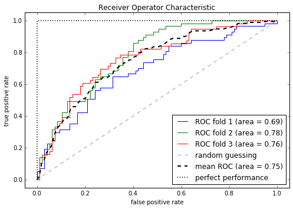

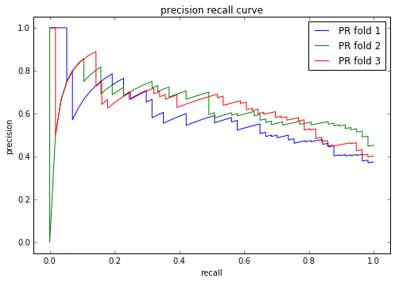

```python
# your code
from sklearn.metrics import roc_curve, auc, precision_recall_curve
from scipy import interp
import matplotlib.pyplot as plt

pipe_lr = Pipeline([('scl', StandardScaler()),
                    ('pca', PCA(n_components=2)),
                    ('clf', LogisticRegression(penalty='l2',
                                               random_state=0,
                                               C=100.0))])

# intentionally use only 2 features to make the task harder and the curves more interesting
X_train2 = X_train[:, [4, 14]]
X_test2 = X_test[:, [4, 14]]


if Version(sklearn_version) < '0.18':
    cv = StratifiedKFold(y_train,
                         n_folds=3,
                         random_state=1)

else:
    cv = list(StratifiedKFold(n_splits=3,
                              random_state=1).split(X_train, y_train))

# plot ROC
fig = plt.figure(figsize=(7, 5))

mean_tpr = 0.0
mean_fpr = np.linspace(0, 1, 100)
all_tpr = []

for i, (train, test) in enumerate(cv):
    probas = pipe_lr.fit(X_train2[train],
                         y_train[train]).predict_proba(X_train2[test])

    fpr, tpr, thresholds = roc_curve(y_train[test],
                                     probas[:, 1],
                                     pos_label=1)
    mean_tpr += interp(mean_fpr, fpr, tpr)
    #mean_tpr[0] = 0.0
    roc_auc = auc(fpr, tpr)
    plt.plot(fpr,
             tpr,
             lw=1,
             label='ROC fold %d (area = %0.2f)'
                   % (i+1, roc_auc))

plt.plot([0, 1],
         [0, 1],
         linestyle='--',
         color=(0.6, 0.6, 0.6),
         label='random guessing')

mean_tpr /= len(cv)
mean_tpr[0] = 0.0
mean_tpr[-1] = 1.0
mean_auc = auc(mean_fpr, mean_tpr)
plt.plot(mean_fpr, mean_tpr, 'k--',
         label='mean ROC (area = %0.2f)' % mean_auc, lw=2)
plt.plot([0, 0, 1],
         [0, 1, 1],
         lw=2,
         linestyle=':',
         color='black',
         label='perfect performance')

plt.xlim([-0.05, 1.05])
plt.ylim([-0.05, 1.05])
plt.xlabel('false positive rate')
plt.ylabel('true positive rate')
plt.title('Receiver Operator Characteristic')
plt.legend(loc="lower right")

plt.tight_layout()
# plt.savefig('./figures/roc.png', dpi=300)
plt.show()

# plot PR
fig = plt.figure(figsize=(7, 5))

mean_pre = 0.0
mean_rec = np.linspace(0, 1, 100)
all_pre = []

for i, (train, test) in enumerate(cv):
    probas = pipe_lr.fit(X_train2[train],
                         y_train[train]).predict_proba(X_train2[test])

    pre, rec, _ = precision_recall_curve(y_train[test],
                                                 probas[:, 1],
                                                 pos_label=1)
    mean_pre += interp(mean_rec, rec, pre)

    plt.plot(rec,
             pre,
             lw=1,
             label='PR fold %d'
                   % (i+1))

plt.xlim([-0.05, 1.05])
plt.ylim([-0.05, 1.05])
plt.xlabel('recall')
plt.ylabel('precision')
plt.title('precision recall curve')
plt.legend(loc="best")

plt.tight_layout()
# plt.savefig('./figures/roc.png', dpi=300)
plt.show()
```

your explanation

TPR = TP / (TP+FN),  
FPR = FP / (FP+TN)

precision = TP / (TP+FP),  
recall = TP / (TP+FN)

Assume we have a imbalanced dataset, where positive class is very rare compared to negative class. One of the real examples is anomaly activities in data center. Say there is 100 incidents in 2 million recorded data.

And we have 2 classifying algorithm:

algo 1: identified 90 over 100  
algo 2: identified 90 over 1000

in ROC,

algo 1: TPR = 90/100=0.9, FPR = 10/1999900  
algo 2: TPR = 90/100=0.9, FPR = 910/1999900  
The difference in FPR is negligible

in PR,

algo 1: precision = 90/100=0.9, recall = 0.9  
algo 2: precision = 90/1000=0.09, recall = 0.9  
The difference in precision is 0.81, which is much obvious than ROC

So the PR has a better result than ROC in imbalanced dataset, especially those with rare positive cases

# Ensemble learning

We have used the following code to compute and plot the ensemble error from individual classifiers for binary classification:

```python
from scipy.misc import comb
import math
import numpy as np

def ensemble_error(num_classifier, base_error):
    k_start = math.ceil(num_classifier/2)
    probs = [comb(num_classifier, k)*(base_error**k)*((1-base_error)**(num_classifier-k)) for k in range(k_start, num_classifier+1)]
    return sum(probs)
```

```python
import matplotlib.pyplot as plt
%matplotlib inline
```

```python
def plot_base_error(ensemble_error_func, num_classifier, error_delta):

    error_range = np.arange(0.0, 1+error_delta, error_delta)
    ensemble_errors = [ensemble_error_func(num_classifier=num_classifier, base_error=error) for error in error_range]

    plt.plot(error_range, ensemble_errors,
             label = 'ensemble error',
             linewidth=2)
    plt.plot(error_range, error_range,
             label = 'base error',
             linestyle = '--',
             linewidth=2)
    plt.xlabel('base error')
    plt.ylabel('base/ensemble error')
    plt.legend(loc='best')
    plt.grid()
    plt.show()
```

```python
num_classifier = 11
error_delta = 0.01
base_error = 0.25
```

```python
print(ensemble_error(num_classifier=num_classifier, base_error=base_error))
```

```
0.034327507019
```

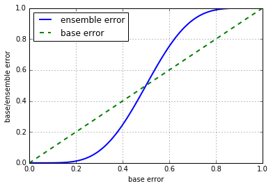

```python
plot_base_error(ensemble_error, num_classifier=num_classifier, error_delta=error_delta)
```

# Number of classifiers (40 points)

The function plot_base_error() above plots the ensemble error as a function of the base error given a fixed number of classifiers.

Write another function to plot ensembe error versus different number of classifiers with a given base error.

Does the ensemble error always go down with more classifiers? Why or why not?

Can you improve the method ensemble_error() to produce a more reasonable plot?

## Answer

The code for plotting is below:

```python
def plot_num_classifier(ensemble_error_func, max_num_classifier, base_error):
    # your code here
    num_clf_range = range(1, max_num_classifier+1)
    ensemble_errors = [ensemble_error_func(num_classifier=num_clf, base_error=base_error) for num_clf in num_clf_range]

    plt.plot(num_clf_range, ensemble_errors,
             label = 'ensemble error',
             linewidth=2)
    plt.xlabel('num of classifiers')
    plt.ylabel('ensemble error')
    plt.legend(loc='best')
    plt.grid()
    plt.show()
```

State your observations of the experiments of your code...

```python
max_num_classifiers = 20
base_error = 0.25
```

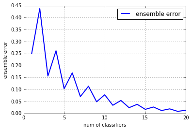

```python
plot_num_classifier(ensemble_error,
                    max_num_classifier=max_num_classifiers,
                    base_error=base_error)
```

Explain your observations above.

Describe a better algorithm for computing the ensemble error.

The ensemble error does not necessarily decrease with number of classifiers. But in general, the more classifiers we have, the ensemble error will decrease. Also, the line increase and decrease in altnerate order.

For a better algorithm, we observe that the error increase when num_classifier is even, we return better_ensemble_error(num_classifier-1, base_error) in this case since we can always choose better result by using one less classifiers

```python
def better_ensemble_error(num_classifier, base_error):
    # replace the following default line with your implementation of a better algorithm for ensemble error
    if (num_classifier % 2 == 1 or num_classifier==0):
        k_start = math.ceil(num_classifier/2)
        probs = [comb(num_classifier, k)*(base_error**k)*((1-base_error)**(num_classifier-k)) for k in range(k_start, num_classifier+1)]
        return sum(probs)
    else:
        return better_ensemble_error(num_classifier-1, base_error)

#     return (sum(probs)+sum(probs2))/2
```

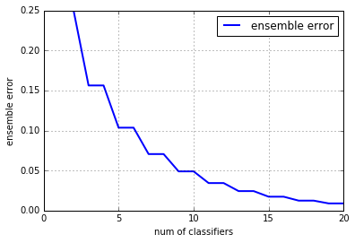

```python
plot_num_classifier(better_ensemble_error,
                    max_num_classifier=max_num_classifiers,
                    base_error=base_error)
```